# proyecto_2_presentacion

15 de marzo de 2017

## 1.- Basic Data Analysis

### 1.1.1.- Description

In this project a survey was conducted on relevant data from UAZ students, which will serve to determine and predict according to the data collected a student's career according to the information that we will mention later.

## 1.1.2.- Prosecution or process

```r
## WE DELETE ALL NULL DATASET INFORMATION.
setwd("C:/Users/Luis/Desktop/8-Semestre/Mineria de Datos/Mini proyectos/AnteProyecto2/mini_proyecto2_mineria")
students_dataset <- read.csv("Encuesta-UAZ.csv", stringsAsFactors = FALSE)
dim(students_dataset)
```

```
## [1] 254  23
```

```r
students_dataset[students_dataset == "NA"] <- NA
students_dataset <- na.omit(students_dataset)
```

## 1.1.3.- Description of variables

- **Horas de estudio por día:** Hours of study per day.
- **Horas de televisión por día:** Hours of television per day.
- **Horas de videojuegos por día:** Hours of video games per day.
- **Horas de actividades sociales por día:** Hours of social activities per day.
- **Horas al dia en la universidad aprox:** Hours per day at the university approx.
- **Promedio académico aprox:** Average Academic.
- **Horas de ejercicio por día:** Hours of exercise per day:.
- **Horas de sueño por día:** Hours of sleep per day.
- **Utilización de transporte público:** If the student Uses the public transport.

## 1.1.3(2).- Description of variables

- **Utilizas el comedor estudiantil:** If student Uses student dining.
- **Tienes alguna beca:** If the student has a scholarship.
- **Materias Repetidas:** If the student repeated a class.
- **Dificultad percibida en la carrera:** Difficulty perceived in the career.
- **Pasión por la carrera:** Passion for the career.
- **Facilidad percibida para ofertas laborales terminando estudios:** Perceived facility for job offers finishing studies.
- **Sueldo estimado que esperas percibir al terminar los estudios (mensual):** Estimated salary you expect to receive at the end of your studies.

## 1.1.3(3).- Description of variables

- **Horas estimadas una vez posicionada en un trabajo fijo:** Estimated hours once positioned in a fixed job.
- **Municipio de origen:** Of which Municipality is its origin.
- **Género:** Gender.
- **Edad:** Age.
- **Carrera:** career.
- **Semestre en el que estás estudiando:**Semester in which you are studying.
- **Que piensas hacer después de salir de la carrera.**What do you plan to do after you leave the university.

## 1.1.4 Dataset

```r
str(students_dataset)
```

```
## 'data.frame':    234 obs. of  23 variables:
##  $ Horas_de_estudio_por_dia                                      : int  0 0 1 0 2 2 2 1 0 1 ...
##  $ Horas_de_television_por_dia                                   : int  1 0 0 0 0 0 1 0 0 0 ...
##  $ Horas_de_videojuegos_por_dia                                  : int  1 0 0 0 0 0 0 0 0 0 ...
##  $ Horas_de_actividades_sociales_por_dia                         : int  1 4 0 3 6 0 3 4 3 2 ...
##  $ Horas_al_dia_en_la_universidad_aprox                          : int  3 2 1 0 1 3 1 2 3 3 ...
##  $ Promedio_academico_aprox                                      : num  7.6 8.6 7 9.3 8 9.3 8 9.9 8 9 ...
##  $ Horas_de_ejercicio_por_dia                                    : int  1 0 1 0 1 0 1 1 1 1 ...
##  $ Horas_de_sueno_por_dia                                        : int  3 5 4 4 1 3 2 3 2 3 ...
##  $ Utilizacion_de_transporte_publico                             : int  1 0 1 1 1 1 1 0 1 1 ...
##  $ Utilizas_el_comedor_estudiantil                               : int  1 0 1 0 0 0 0 0 0 0 ...
##  $ Tienes_alguna_beca                                            : int  1 0 0 0 1 0 0 0 0 1 ...
##  $ Materias_repetidas                                            : chr  "0" "1" "1" "0" ...
##  $ dificultad_percibida_de_la_carrera                            : int  2 1 2 2 2 2 2 2 2 2 ...
##  $ Pasion_por_la_carrera                                         : int  5 10 8 9 8 10 8 10 6 7 ...
##  $ Facilidad_percibida_para_ofertas_laborales_terminando_estudios: int  7 5 1 10 7 10 8 8 10 5 ...
##  $ Sueldo_estimado_que_esperas_percibir_al_terminar_los_estudios : int  1 2 2 1 3 4 1 4 2 3 ...
##  $ Horas_estimadas_una_vez_posicionada_en_un_trabajo_fijo        : int  2 2 2 2 1 2 3 2 1 2 ...
##  $ Municipio_de_origen                                           : chr  "CALERA" "ZACATECAS" "JEREZ" "MONTE ESCOBEDO" ...
##  $ Genero                                                        : int  1 0 1 1 0 1 0 0 1 0 ...
##  $ Edad                                                          : int  20 21 28 21 21 23 19 20 22 21 ...
##  $ Carrera                                                       : chr  "INGENIERIA EN AGRONOMIA" "LICENCIATURA EN ARQUITECTURA" "LICENCIATURA EN BIOLOGIA" "CIENCIAS Y TECNICAS DE LA COMUNICACION" ...
##  $ semestre_en_el_que_estas_estudiando                           : int  4 8 8 10 8 9 4 4 6 6 ...
##  $ Que_piensas_hacer_despues_de_salir_de_la_carrera              : int  1 1 1 1 0 0 0 1 0 0 ...
##  - attr(*, "na.action")=Class 'omit'  Named int [1:20] 4 6 9 15 87 118 125 128 131 165 ...
##   .. ..- attr(*, "names")= chr [1:20] "4" "6" "9" "15" ...
```

## 1.2.- How data was recolected

The data were collected through a form filled out by UAZ students. The students were invited to collaborate in this survey and in this way we collect the data.

## 1.2.1 Limitations and disadvantages

- **False information.**
- **Corrupt data.**

## 1.3.- Basic Summary Statistics

```r
summary(students_dataset)
```

```
##  Horas_de_estudio_por_dia Horas_de_television_por_dia
##  Min.   :0.000            Min.   :0.0000
##  1st Qu.:1.000            1st Qu.:0.0000
##  Median :1.000            Median :0.0000
##  Mean   :1.094            Mean   :0.4359
##  3rd Qu.:1.000            3rd Qu.:1.0000
##  Max.   :3.000            Max.   :2.0000
##  Horas_de_videojuegos_por_dia Horas_de_actividades_sociales_por_dia
##  Min.   :0.0000               Min.   : 0.000
##  1st Qu.:0.0000               1st Qu.: 1.000
##  Median :0.0000               Median : 2.000
##  Mean   :0.2906               Mean   : 2.085
##  3rd Qu.:1.0000               3rd Qu.: 3.000
##  Max.   :2.0000               Max.   :10.000
##  Horas_al_dia_en_la_universidad_aprox Promedio_academico_aprox
##  Min.   :0.000                        Min.   : 1.000
##  1st Qu.:2.000                        1st Qu.: 8.000
##  Median :3.000                        Median : 8.500
##  Mean   :2.389                        Mean   : 8.398
##  3rd Qu.:3.000                        3rd Qu.: 9.000
##  Max.   :3.000                        Max.   :10.000
##  Horas_de_ejercicio_por_dia Horas_de_sueno_por_dia
##  Min.   :0.0000             Min.   :1.000
##  1st Qu.:0.0000             1st Qu.:2.000
##  Median :0.0000             Median :3.000
##  Mean   :0.4017             Mean   :2.603
##  3rd Qu.:1.0000             3rd Qu.:3.000
##  Max.   :1.0000             Max.   :5.000
##  Utilizacion_de_transporte_publico Utilizas_el_comedor_estudiantil
##  Min.   :0.0000                    Min.   :0.0000
##  1st Qu.:1.0000                    1st Qu.:0.0000
##  Median :1.0000                    Median :0.0000
##  Mean   :0.8077                    Mean   :0.4402
##  3rd Qu.:1.0000                    3rd Qu.:1.0000
##  Max.   :1.0000                    Max.   :1.0000
##  Tienes_alguna_beca Materias_repetidas dificultad_percibida_de_la_carrera
##  Min.   :0.0000     Length:234         Min.   :1.000
##  1st Qu.:0.0000     Class :character   1st Qu.:2.000
##  Median :0.0000     Mode  :character   Median :2.000
##  Mean   :0.2991                        Mean   :2.368
```

[output cut: 36 more lines]

```
##                      Max.   :1.0000   Max.   :40.00
##  semestre_en_el_que_estas_estudiando
##  Min.   : 1.00
##  1st Qu.: 4.00
##  Median : 6.00
##  Mean   : 5.94
##  3rd Qu.: 8.00
##  Max.   :11.00
##  Que_piensas_hacer_despues_de_salir_de_la_carrera
##  Min.   :0.0000
##  1st Qu.:0.0000
##  Median :1.0000
##  Mean   :0.5128
##  3rd Qu.:1.0000
##  Max.   :1.0000
```

## 1.3.1 Minimum and Maximum

**Minimum:**lowest avarage academic :

```r
avarage_academic_min <- min(students_dataset$Promedio_academico_aprox, na.rm = TRUE)
print(avarage_academic_min)
```

```
## [1] 1
```

```r
subset(students_dataset,Promedio_academico_aprox   == min(students_dataset$Promedio_academico_aprox, na.rm = TRUE))[c(1,6,21)]
```

```
##    Horas_de_estudio_por_dia Promedio_academico_aprox
## 55                        1                        1
## 57                        1                        1
## 58                        1                        1
##                   Carrera
## 55 INGENIERIA DE SOFTWARE
## 57 INGENIERIA DE SOFTWARE
## 58 INGENIERIA DE SOFTWARE
```

Passion of the career.

```r
passion_career_min <- min(students_dataset$Pasion_por_la_carrera)
head(subset(students_dataset, Pasion_por_la_carrera == min(students_dataset$Pasion_por_la_carrera, na.rm = TRUE)))[c(1,21)]
```

```
##     Horas_de_estudio_por_dia Carrera
## 249                        1
```

## 1.3.1 Minimum and Maximum

**Maximum**: Highest avarage academic

```r
avarage_academic_max <- max(students_dataset$Promedio_academico_aprox, na.rm = TRUE)
print(avarage_academic_max)
```

```
## [1] 10
```

```r
head(subset(students_dataset,Promedio_academico_aprox  == max(students_dataset$Promedio_academico_aprox, na.rm = TRUE)))[c(1,6,21)]
```

```
##     Horas_de_estudio_por_dia Promedio_academico_aprox
## 14                         1                       10
## 94                         1                       10
## 119                        1                       10
## 144                        0                       10
##                        Carrera
## 14  LICENCIATURA EN CONTADURIA
## 94      INGENIERIA DE SOFTWARE
## 119         INGENIERIA QUIMICA
## 144                      LILEX
```

Passion of the career.

```r
passion_career_max <- max(students_dataset$Pasion_por_la_carrera)
head(subset(students_dataset, Pasion_por_la_carrera == max(students_dataset$Pasion_por_la_carrera, na.rm = TRUE)))[c(1,21)]
```

```
##    Horas_de_estudio_por_dia                                    Carrera
## 2                         0               LICENCIATURA EN ARQUITECTURA
## 8                         2 INGENIERIA EN COMUNICACIONES Y ELECTRONICA
## 11                        1                 LICENCIATURA EN CONTADURIA
## 17                        1                               CRIMINOLOGIA
## 18                        0                               CRIMINOLOGIA
## 22                        1                    LICENCIATURA EN DERECHO
```

## 1.3.2 Mean

\[\sigma = \frac{\sum\limits_{i=1}^N x(i)}{N}\]

The sum of the sample values divided by the number of samples in the example.

### Mean of the academic average of students.

```r
mean(students_dataset$Promedio_academico_aprox, na.rm = TRUE)
```

```
## [1] 8.39812
```

## 1.3.2 Mean

### Mean of the passion of the career.

```r
mean(students_dataset$Pasion_por_la_carrera, na.rm = TRUE)
```

```
## [1] 8.632479
```

### Mean of the age of students.

```r
mean(students_dataset$Edad, na.rm = TRUE)
```

```
## [1] 21.09402
```

## 1.3.3 Median

\[\\Mediana=L_{i-1}+\frac{\frac{N}{2}-N_{i-1}}{n_i}{a_i}\] Represents the value of the central position variable in an ordered data set.

### Median of the academic average of students.

```r
median(students_dataset$Promedio_academico_aprox, na.rm = TRUE)
```

```
## [1] 8.5
```

## 1.3.3 Median

### Median of the passion of the career.

```r
median(students_dataset$Pasion_por_la_carrera, na.rm = TRUE)
```

```
## [1] 9
```

### Median of the age of students.

```r
median(students_dataset$Edad, na.rm = TRUE)
```

```
## [1] 21
```

## 1.4.- Boxplots Interpretation

It shows the mean of the academic average in which it is around the 9 and 8.

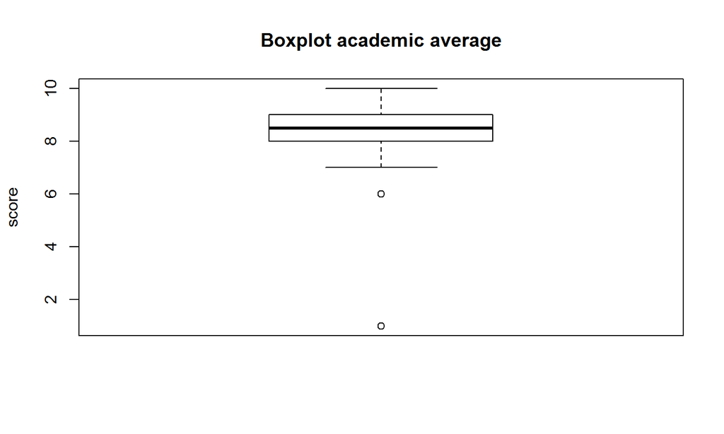

```r
boxplot(students_dataset$Promedio_academico_aprox,
     main = "Boxplot academic average",
     ylab = "score")
```

## 1.5.- Skew of Data Interpretation

\[CAp = \frac{\overline{x}-{Mo}{(X)}}{s}\]

Being \[\overline{x}\] the mean, Mo (X) the mode and s the typical deviation

The result is negative indicates that the average values are less than the mean, if it is positive they are higher.

## 1.5.- Skew of Data Interpretation

```r
library(moments)

skewness(na.omit(students_dataset$Promedio_academico_aprox))
```

```
## [1] -4.099523
```

```r
skewness(na.omit(students_dataset$Pasion_por_la_carrera))
```

```
## [1] -1.679668
```

## 1.7.- Quartiles Interpretation

## 1.8.- Correlation Interpretation

## 1.9.- Scatterplots Interpretation

## 2.- K - Nearest Neighbors

KNN is a supervised classified method that classifies by characteristics of unlabeled examples by assigning t a class of similar label. The succes of this algorithm depends on the prediction, and the amount of data given. But if the given data is noisy and there is no clear distinction among the groups, the nearest neighborg algorithms may struggle to identify the class boundaries.

Strenghts - Simple and effective. - Makes no assumptions abouthe the underlying data distribution. - Fast training phase.

Weaknesses - Doesn't produces a model, limiting the ability to understand how features are related to a class. - Requieres selection of appropiate **k value**. - Slow classification phase. - Nominal features and missing data requiere addtional processing.

## 2.1.- Normalization

Before applying kNN algorithm, the first step is to apply a normalization method so features independent of their types get standarized. Lets say, if certain features have a larger range value than others, the distance measurements will be strongly dominated by the larger range values.

For reasons of the Data Mining class, we will be using "Min Max Normalization" and "Z Score Normalization".

## 2.1.1 Method 1 (Min Max Normaliztion)

```r
minmax_normalization <- function(x_value){
  return ((x - min(x_value)) / min(x_value) - max(x_value))
} # minmax_normalization

#students_questionary <- as.data.frame(lapply(data[,c(1,4)], minmax_normalizations))
```

## 2.1.2 Method 2 (Z Score Normalization)

There is also "z-score standardization". Which subtracts the mean value of feature x, and divides the outcome by the standard deviation of x as follows:

\[x_{new} = \frac{x - \mu}{\sigma} - \frac{x - mean(x)}{stdev(x)}\]

Basically this method rescales each of the feature's values in terms of how many standard deviations they fall above or below the mean value. The resulting value is called a z-score. The z-scores fall in an unbound range of negative and positive numbers. Unlike the normalized values, they have no predefined minimum and maximum.

## 2.4.- Trainning & Testing Sets

## 2.5.- Determination of the "Optimal K"

## 2.6.- KNN Classification Outputs

## 2.7 Frequency Table & Interpretation

## 3.- Conclusions & Limitations